# Time Series Forecasting of APPLE Stock Prices using Python

In this Jupyter notebook, we will be utilizing techniques from the field of time series analysis to analyze the historical stock prices of APPLE. We will be using tools from the Python ecosystem such as the yfinance library to retrieve the data and various forecasting models to make predictions about future stock prices.

We will start by importing the necessary libraries and loading the historical stock data for APPLE. Next, we will perform exploratory data analysis to gain a better understanding of the trends and patterns in the stock prices.

After that, we will use techniques of time series analysis to create a model that can predict future stock prices. This will include techniques like decomposition, stationarity testing and feature engineering.

Overall, the goal of this notebook is to gain a deeper understanding of the stock market trends of APPLE and make informed predictions about its future performance using the techniques of time series analysis and modeling.

## Importing data

First, we will start by importing the necessary libraries and loading the historical stock data for APPLE using the yfinance library.

```python
import yfinance as yf
import matplotlib.pyplot as plt
import pandas as pd
import numpy as np
```

```python
df = yf.download('AAPL',interval="1d")
```

```
[*********************100%***********************]  1 of 1 completed
```

```python
df.head()
```

| Date | Open | High | Low | Close | Adj Close | Volume |
| --- | --- | --- | --- | --- | --- | --- |
| 1980-12-12 | 0.128348 | 0.128906 | 0.128348 | 0.128348 | 0.099722 | 469033600 |
| 1980-12-15 | 0.122210 | 0.122210 | 0.121652 | 0.121652 | 0.094519 | 175884800 |
| 1980-12-16 | 0.113281 | 0.113281 | 0.112723 | 0.112723 | 0.087582 | 105728000 |
| 1980-12-17 | 0.115513 | 0.116071 | 0.115513 | 0.115513 | 0.089749 | 86441600 |
| 1980-12-18 | 0.118862 | 0.119420 | 0.118862 | 0.118862 | 0.092351 | 73449600 |

```python
df.tail()
```

| Date | Open | High | Low | Close | Adj Close | Volume |
| --- | --- | --- | --- | --- | --- | --- |
| 2023-02-07 | 150.639999 | 155.229996 | 150.639999 | 154.649994 | 154.414230 | 83322600 |
| 2023-02-08 | 153.880005 | 154.580002 | 151.169998 | 151.919998 | 151.688400 | 64120100 |
| 2023-02-09 | 153.779999 | 154.330002 | 150.419998 | 150.869995 | 150.639999 | 56007100 |
| 2023-02-10 | 149.460007 | 151.339996 | 149.220001 | 151.009995 | 151.009995 | 57409100 |
| 2023-02-13 | 150.949997 | 154.259995 | 150.919998 | 153.850006 | 153.850006 | 62123800 |

## Exploratory analysis

We will perform some basic exploratory data analysis to gain a better understanding of the trends and patterns in the stock prices.

```python
ts=df.Close
```

```python
ts.isna().sum()
```

```
0
```

## Dealing with missing values

```python
time_index = pd.date_range(df.index[0],end=df.index[-1],  freq="d")
dft = pd.DataFrame(index=time_index)
```

```python
ts_withna=dft.merge(ts,how='left',left_index=True, right_index=True)
```

```python
ts_withna.isna().sum()
```

```
Close    4772
dtype: int64
```

```python
ts_=ts_withna.interpolate()
```

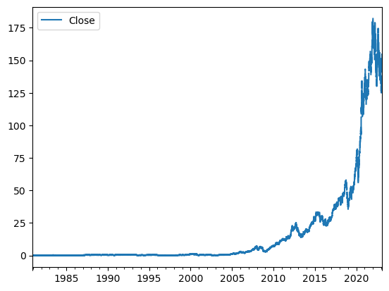

```python
ts_withna.plot()
```

## Data visualisation

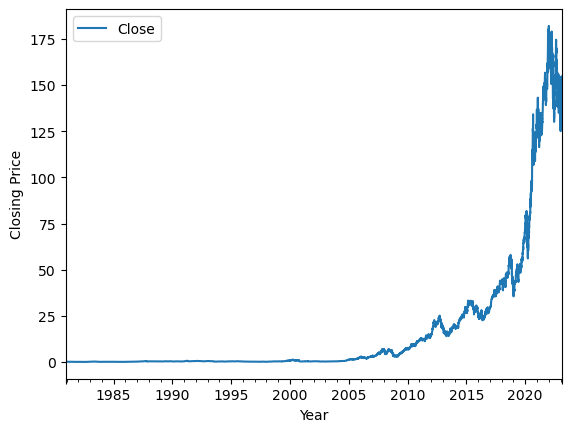

```python
ts_.plot()
plt.xlabel('Year')
plt.ylabel('Closing Price')
```

In order to continue making our analysis easier, we are going to analyse the historical prices starting at the year 2015.

```python
ts_=ts_.loc['2015-01-01':]
```

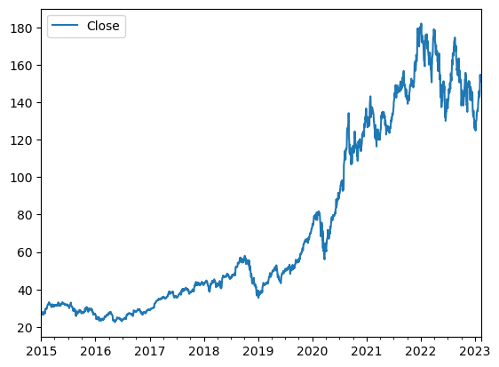

```python
ts_.plot()
```

We can also use various statistical measures to gain a better understanding of the stock prices.

```python
mean_price = ts_.mean()
median_price = ts_.median()
std_price = ts_.std()

print(f'Mean: {mean_price}, Median: {median_price}, Standard Deviation: {std_price}')
```

```
Mean: Close    73.954768
dtype: float64, Median: Close    48.539999
dtype: float64, Standard Deviation: Close    49.269371
dtype: float64
```

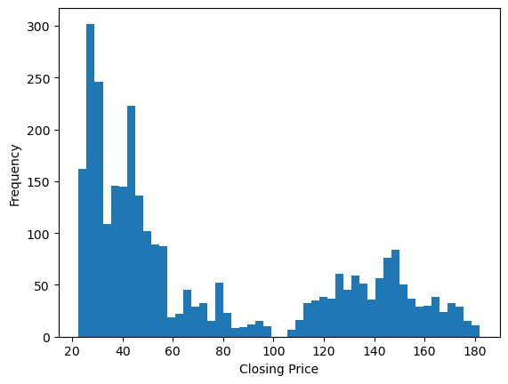

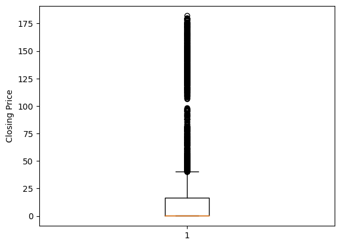

```python
# Plot a histogram of the closing prices
plt.hist(ts_, bins=50)
plt.xlabel('Closing Price')
plt.ylabel('Frequency')
plt.show()

# Plot a box plot of the closing prices
plt.boxplot(ts)
plt.ylabel('Closing Price')
plt.show()
```

Note that this is just a basic exploratory data analysis and there are many other methods and techniques that can be used to gain a better understanding of the data.

## Time series descomposition

Once we have a better understanding of the data through exploratory data analysis, we can now proceed to the next step which is time series decomposition.

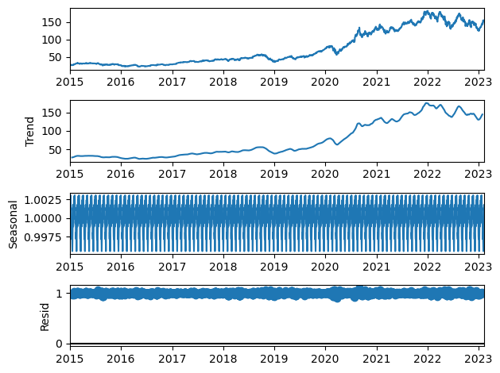

```python
from statsmodels.tsa.seasonal import seasonal_decompose

# Perform time series decomposition
result = seasonal_decompose(ts_, model='multiplicative',period=30)
result.plot()
plt.show()
```

Additionally, by specifying the frequency, you can better understand the underlying patterns in the data and make more accurate predictions. For example, if you know that there is a yearly pattern in the time series, specifying a daily frequency will allow you to see this pattern more clearly.

Next, we will perform stationarity testing to check if our time series is stationary. A time series is stationary if the mean, variance and covariance are constant over time.

```python
from statsmodels.tsa.stattools import adfuller

# Perform Dickey-Fuller test
dftest = adfuller(ts_)
print(f'p-value: {dftest[1]}')
```

```
p-value: 0.9321115016347086
```

A p-value less than 0.05 indicates that the time series is stationary. Since, our p-value is greater than that value, we need to make the time series stationary in order to be able to model it.

```python
#Differencing
ts1= ts_ - ts_.shift(1)

#Test stationarity
resultp = adfuller(ts1.dropna())
print('p-value: ', resultp[1])
```

```
p-value:  3.84564048489496e-21
```

We can see now that our time series has become stationary. The plot of the data would look like:

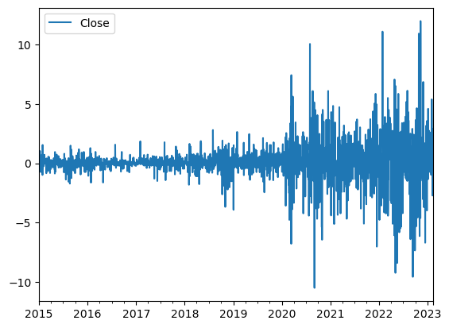

```python
ts1.plot()
```

```python
ts1
```

|  | Close |
| --- | --- |
| 2015-01-01 | NaN |
| 2015-01-02 | -0.131249 |
| 2015-01-03 | -0.256667 |
| 2015-01-04 | -0.256667 |
| 2015-01-05 | -0.256667 |
| ... | ... |
| 2023-02-09 | -1.050003 |
| 2023-02-10 | 0.139999 |
| 2023-02-11 | 0.946671 |
| 2023-02-12 | 0.946671 |
| 2023-02-13 | 0.946671 |

2966 rows × 1 columns

We have a missing value due to the differentiation. Then, we have to remove the first observation:

```python
ts1=ts1[1:]
```

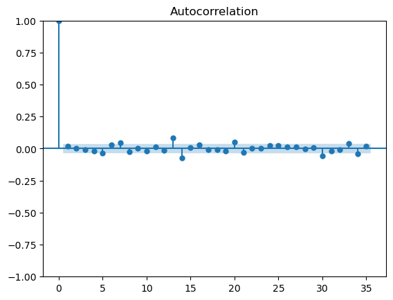

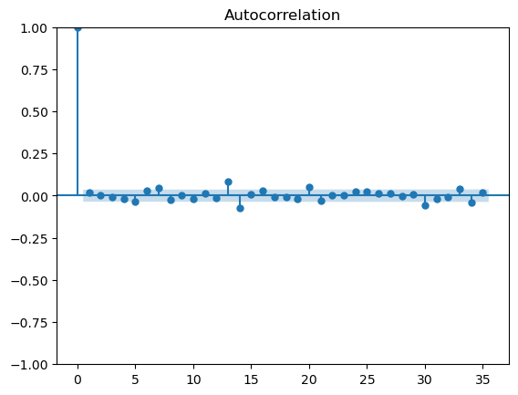

```python
from statsmodels.graphics.tsaplots import plot_acf, plot_pacf
plot_acf(ts1)
```

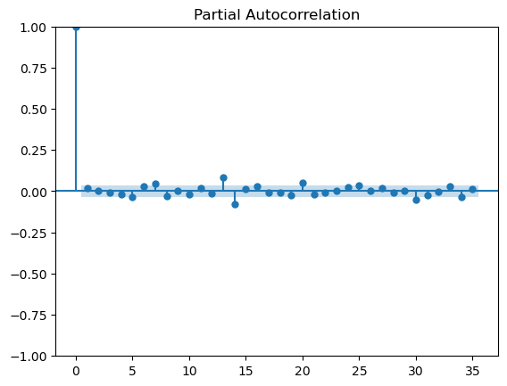

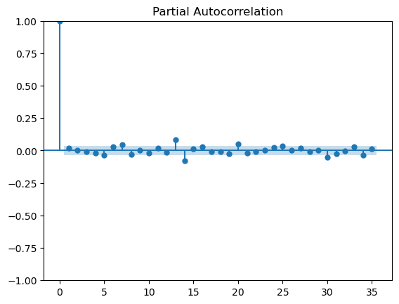

```python
plot_pacf(ts1)
```

### Classic modeling

```python
import pmdarima as pm
```

```python
result.resid.head(40)
```

```
2015-01-01         NaN
2015-01-02         NaN
2015-01-03         NaN
2015-01-04         NaN
2015-01-05         NaN
2015-01-06         NaN
2015-01-07         NaN
2015-01-08         NaN
2015-01-09         NaN
2015-01-10         NaN
2015-01-11         NaN
2015-01-12         NaN
2015-01-13         NaN
2015-01-14         NaN
2015-01-15         NaN
2015-01-16    0.962578
2015-01-17    0.967333
2015-01-18    0.971607
2015-01-19    0.973270
2015-01-20    0.974265
2015-01-21    0.976002
2015-01-22    0.997192
2015-01-23    0.998694
2015-01-24    0.999768
2015-01-25    0.997550
2015-01-26    0.994008
2015-01-27    0.953947
2015-01-28    1.003417
2015-01-29    1.028469
2015-01-30    1.008904
2015-01-31    1.005555
2015-02-01    1.004328
2015-02-02    1.004203
2015-02-03    0.999298
2015-02-04    0.998171
2015-02-05    0.996426
2015-02-06    0.983642
2015-02-07    0.981329
2015-02-08    0.977993
2015-02-09    0.976944
Freq: D, Name: resid, dtype: float64
```

```python
resid=result.resid.dropna(axis = 0, how = 'any')
```

```python
train=ts_[2036:-30]
test=ts_[-30:]
```

```python
train
```

|  | Close |
| --- | --- |
| 2020-07-29 | 95.040001 |
| 2020-07-30 | 96.190002 |
| 2020-07-31 | 106.260002 |
| 2020-08-01 | 107.152501 |
| 2020-08-02 | 108.045001 |
| ... | ... |
| 2023-01-10 | 130.729996 |
| 2023-01-11 | 133.490005 |
| 2023-01-12 | 133.410004 |
| 2023-01-13 | 134.759995 |
| 2023-01-14 | 135.054996 |

900 rows × 1 columns

```python
test.head(30)
```

|  | Close |
| --- | --- |
| 2023-01-15 | 135.349998 |
| 2023-01-16 | 135.645000 |
| 2023-01-17 | 135.940002 |
| 2023-01-18 | 135.210007 |
| 2023-01-19 | 135.270004 |
| 2023-01-20 | 137.869995 |
| 2023-01-21 | 138.949997 |
| 2023-01-22 | 140.029999 |
| 2023-01-23 | 141.110001 |
| 2023-01-24 | 142.529999 |
| 2023-01-25 | 141.860001 |
| 2023-01-26 | 143.960007 |
| 2023-01-27 | 145.929993 |
| 2023-01-28 | 144.953328 |
| 2023-01-29 | 143.976664 |
| 2023-01-30 | 143.000000 |
| 2023-01-31 | 144.289993 |
| 2023-02-01 | 145.429993 |
| 2023-02-02 | 150.820007 |
| 2023-02-03 | 154.500000 |
| 2023-02-04 | 153.576665 |
| 2023-02-05 | 152.653330 |
| 2023-02-06 | 151.729996 |
| 2023-02-07 | 154.649994 |
| 2023-02-08 | 151.919998 |
| 2023-02-09 | 150.869995 |
| 2023-02-10 | 151.009995 |
| 2023-02-11 | 151.956665 |
| 2023-02-12 | 152.903336 |
| 2023-02-13 | 153.850006 |

```python
import multiprocessing as mp
print("Number of processors: ", mp.cpu_count())
```

```
Number of processors:  8
```

```python
model = pm.auto_arima(train ,d=1 ,D=1, m=7, trace=True)

model.fit(train)
```

```
Performing stepwise search to minimize aic
 ARIMA(2,1,2)(1,1,1)[7]             : AIC=inf, Time=1.98 sec
 ARIMA(0,1,0)(0,1,0)[7]             : AIC=4555.521, Time=0.05 sec
 ARIMA(1,1,0)(1,1,0)[7]             : AIC=4378.262, Time=0.15 sec
 ARIMA(0,1,1)(0,1,1)[7]             : AIC=inf, Time=0.71 sec
 ARIMA(1,1,0)(0,1,0)[7]             : AIC=4557.347, Time=0.09 sec
 ARIMA(1,1,0)(2,1,0)[7]             : AIC=4263.999, Time=0.29 sec
 ARIMA(1,1,0)(2,1,1)[7]             : AIC=inf, Time=2.31 sec
 ARIMA(1,1,0)(1,1,1)[7]             : AIC=inf, Time=1.02 sec
 ARIMA(0,1,0)(2,1,0)[7]             : AIC=4262.046, Time=0.22 sec
 ARIMA(0,1,0)(1,1,0)[7]             : AIC=4376.325, Time=0.13 sec
 ARIMA(0,1,0)(2,1,1)[7]             : AIC=inf, Time=1.97 sec
 ARIMA(0,1,0)(1,1,1)[7]             : AIC=inf, Time=0.93 sec
 ARIMA(0,1,1)(2,1,0)[7]             : AIC=4264.000, Time=0.31 sec
 ARIMA(1,1,1)(2,1,0)[7]             : AIC=4265.979, Time=1.08 sec
 ARIMA(0,1,0)(2,1,0)[7] intercept   : AIC=4264.019, Time=0.55 sec

Best model:  ARIMA(0,1,0)(2,1,0)[7]
Total fit time: 11.784 seconds
```

```
 ARIMA(0,1,0)(2,1,0)[7]
```

```python
pred=model.predict(n_periods=30)
```

```python
pred
```

```
2023-01-15    134.686269
2023-01-16    134.317541
2023-01-17    134.116505
2023-01-18    134.151913
2023-01-19    135.070787
2023-01-20    136.807162
2023-01-21    136.541263
2023-01-22    135.999412
2023-01-23    135.457561
2023-01-24    135.078549
2023-01-25    136.186331
2023-01-26    136.076382
2023-01-27    138.735452
2023-01-28    138.755438
2023-01-29    138.507456
2023-01-30    138.259473
2023-01-31    138.260433
2023-02-01    139.704467
2023-02-02    139.842631
2023-02-03    141.826091
2023-02-04    141.877254
2023-02-05    141.518758
2023-02-06    141.160261
2023-02-07    141.002116
2023-02-08    141.870760
2023-02-09    142.227515
2023-02-10    144.279646
2023-02-11    144.211573
2023-02-12    143.813800
2023-02-13    143.416028
Freq: D, dtype: float64
```

[output not shown]

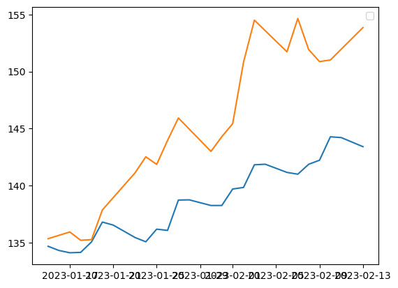

```python
plt.plot(pred)
plt.plot(test)
```

```python
fore_redec=pd.DataFrame(forecast.values*result.seasonal[-30:].values*result.trend[-30:].values)
```

```python
forecast
```

[output not shown]

### Validation

```python
result.resid,result.seasonal
```

[output not shown]

```python
ts_.rolling(30).mean().dropna()
```

[output not shown]